# Milwaukee Bucks Shot Zone Analysis

2022-23 NBA Season

Analytics Intern

2026-04-01

# 1. Shot Chart — Individual Shots

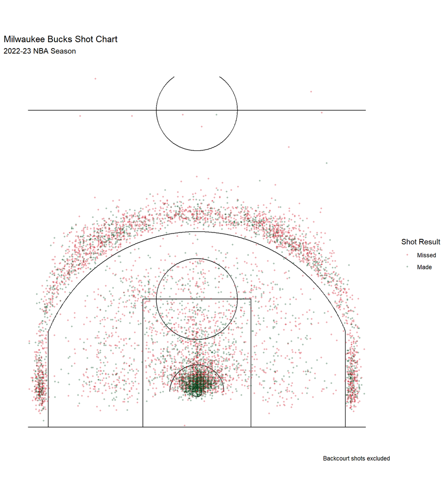

# 2. Zone Shooting Statistics

```
## # A tibble: 9 × 6
##   custom_zone     attempts makes shoot_pct    mean_x mean_y
##   <chr>              <int> <int>     <dbl>     <dbl>  <dbl>
## 1 Left Corner 3        145    64     0.441 -227.       96.1
## 2 Left Wing 3          773   290     0.375 -156.      216.
## 3 Mid Range Left       749   296     0.395 -173.       43.9
## 4 Mid Range Right      660   258     0.391  180.       44.2
## 5 Mid Range Top         60    25     0.417    0.85    204.
## 6 Paint               3334  1972     0.591    0.0282   38.4
## 7 Right Corner 3       146    47     0.322  226.       98.1
## 8 Right Wing 3         704   249     0.354  151.      217.
## 9 Top of Key 3         835   303     0.363    5.15    260.
```

# 3. Zone Efficiency Chart

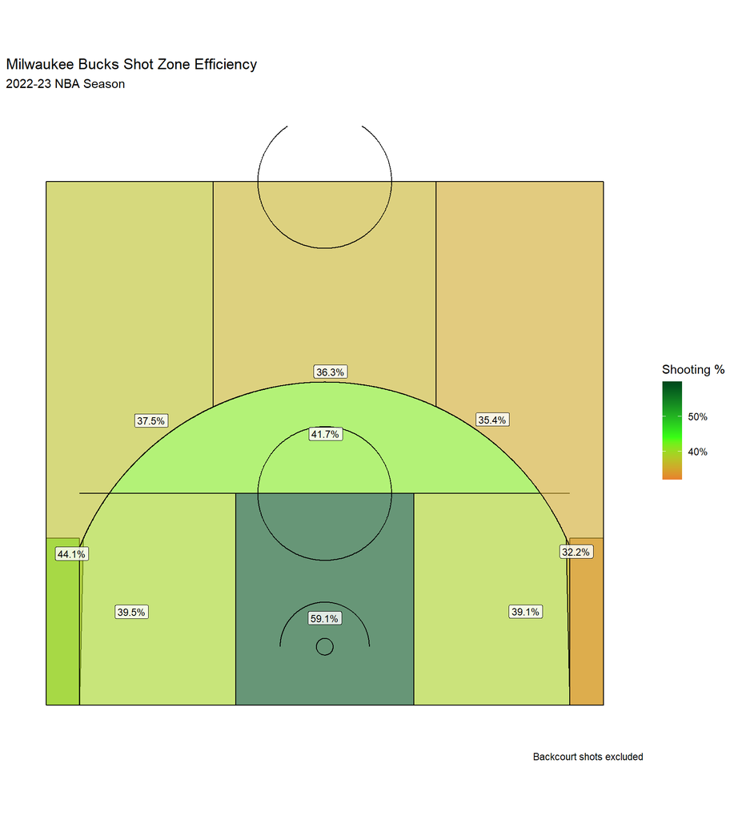

# 4. Key Findings

## Summary

- **Paint dominates efficiency:** The Bucks convert nearly 59% of shots in the restricted area/paint, more than any other zone
- **Corner three disparity:** The left corner shooting percentage (44%) is way higher than the right corner (32%)
- **Mid-range is consistent:** All three mid-range zones sit between 39-42%, just below league average
- **Wing threes underperform:** Both wings sit around 35-37%, suggesting the team should seek higher quality three point looks

## Detailed Findings

### Paint Efficiency (59.1%, 3,334 attempts)

The paint is by far the most efficient zone at 59.1%. This suggests the Bucks are effective at generating high-percentage looks near the basket, whether through drives, post-ups, or offensive rebounds.I would assume this is largely because of Giannis. A dominating paint presence.

### Left vs. Right Corner Three (44.1% vs. 32.2%)

This 12-point gap is the most striking finding in the data. Corner threes are generally considered the most efficient three-point shots in basketball due to the shorter distance (22 ft vs. 23.75 ft). The Bucks are capitalizing on this on the left side but not the right. This asks the question — which players are taking right corner threes, and are defensive rotations forcing lower-quality looks to that spot?

### Mid-Range Zones (39–42%)

Mid-range shots are widely regarded as the least efficient shot type in modern basketball — too far for a high percentage, too close to count for three points. The Bucks’ 39–42% from these zones is roughly average. The very low volume from mid-range top (60 attempts) suggests the team is already limiting these looks, which is consistent with modern offensive strategy.

### Wing Threes (35.4% right, 37.5% left)

Wing threes account for a combined 1,477 attempts — a significant portion of the shot profile. At 35–37%, these are below the efficiency threshold many teams target (~38%+) for high-volume three-point zones. Improving shot quality in these zones (e.g., more open looks off movement) or shifting volume toward the corners could improve overall offensive efficiency.

# 5. Four Point Line Suggestions

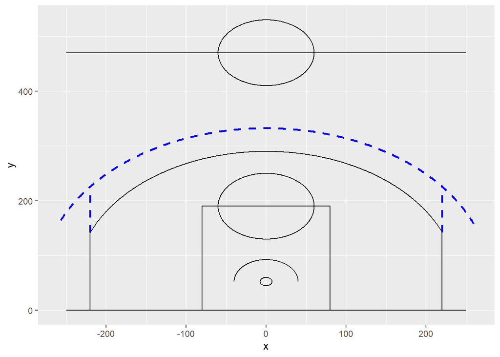

## Arc shape:

The 4-point arc follows the same shape as the existing 3-point arc — a circular arc with a radius of 28 feet.

## Consequence:

Grayson Allen would be the biggest beneficiary on the 2022-23 Bucks roster. He made 19 shots from beyond 28 feet, which currently count for 57 total points. Under a 4-point rule, those same makes would be worth 76 points — an increase of approximately 3% in his total season point output. While not much, this would meaningfully reward players who are good at shooting from deep and could change how teams construct rosters.